# Análise Multivariada

Prof. Ricardo Limongi

2025-03-04

# Preparação de Dados para Análise Multivariada

Este primeiro script abordará os seguintes aspectos para nosso módulo de Análise Multivariada:

1. Introdução
2. Identificação e tratamento de valores ausentes e outliers
3. Métodos de padronização e transformação de dados
4. Análise exploratória básica de dados multivariados

Verificação e Instalação de Pacotes Necessários (será útil quando quiserem rodar durante os estudos)

Primeiro, vamos verificar se os pacotes necessários estão instalados e, caso não estejam, realizaremos a instalação automaticamente:

```r
# Lista de pacotes necessários
pacotes_necessarios <- c("tidyverse", "naniar", "VIM", "corrplot", "psych",
                         "outliers", "car", "GGally")

# Função para verificar e instalar pacotes
verificar_instalar_pacotes <- function(pacotes) {
  pacotes_nao_instalados <- pacotes[!(pacotes %in% installed.packages()[,"Package"])]

  if(length(pacotes_nao_instalados) > 0) {
    cat("Instalando os seguintes pacotes:", paste(pacotes_nao_instalados, collapse = ", "), "\n")
    install.packages(pacotes_nao_instalados, dependencies = TRUE)
    cat("Instalação concluída!\n\n")
  } else {
    cat("Todos os pacotes necessários já estão instalados!\n\n")
  }

  # Carregar todos os pacotes
  cat("Carregando pacotes...\n")
  invisible(lapply(pacotes, require, character.only = TRUE))
  cat("Todos os pacotes foram carregados com sucesso!\n")
}

# Verificar e instalar pacotes
verificar_instalar_pacotes(pacotes_necessarios)
```

```
## Todos os pacotes necessários já estão instalados!
##
## Carregando pacotes...
```

```
## Todos os pacotes foram carregados com sucesso!
```

## 1. Introdução

A análise estatística pode ser dividida em **univariada** e **multivariada**. Enquanto a **análise univariada** examina cada variável individualmente, a **análise multivariada** estuda múltiplas variáveis simultaneamente, identificando relações e padrões.

A análise multivariada é fundamental na área da saúde porque grande parte dos fenômenos estudados envolve múltiplas variáveis inter-relacionadas. Pacientes não apresentam sintomas isolados, mas um conjunto de fatores fisiológicos, clínicos e laboratoriais que precisam ser analisados em conjunto para uma melhor compreensão do quadro clínico. Além disso, a medicina baseada em evidências depende da identificação de padrões em grandes volumes de dados para suportar diagnósticos e decisões terapêuticas.

**Aplicações Práticas da Análise Multivariada na Saúde**

- Identificação de Perfis de Pacientes: Técnicas como Análise de Cluster ajudam a segmentar pacientes com base em características clínicas e demográficas, permitindo abordagens terapêuticas personalizadas.
- Redução de Dimensionalidade em Exames Médicos: A Análise de Componentes Principais (PCA) é usada para sintetizar grandes quantidades de informações em exames como ressonâncias magnéticas, reduzindo redundâncias sem perder informações críticas.
- Diagnósticos Diferenciais: A Análise Discriminante auxilia na diferenciação de grupos de pacientes com doenças semelhantes, aumentando a precisão dos diagnósticos.
- Predição de Riscos e Prognósticos: Modelos multivariados permitem prever riscos de doenças crônicas e avaliar a eficácia de intervenções médicas, contribuindo para a medicina preditiva.
- Estudos Epidemiológicos: A análise fatorial é útil para identificar fatores de risco comuns em grandes populações, ajudando na formulação de políticas públicas.

## Diferença entre Análise Univariada e Multivariada

- **Análise Univariada**: Examina uma variável por vez. Estatísticas descritivas como média, mediana e desvio-padrão são utilizadas.
- **Análise Multivariada**: Examina múltiplas variáveis ao mesmo tempo, buscando correlações e padrões complexos.

## Conceitos Fundamentais

1. Tipos de Variáveis

As variáveis em uma análise multivariada podem ser classificadas de acordo com suas características:

1. Variáveis Quantitativas (Numéricas)
- Contínuas: Podem assumir qualquer valor dentro de um intervalo (exemplo: pressão arterial, altura, IMC).
- Discretas: Assumem valores específicos e contáveis (exemplo: número de consultas médicas realizadas no último ano).
2. Variáveis Qualitativas (Categóricas)
- Nominais: Sem ordem natural entre as categorias (exemplo: tipo sanguíneo, sexo).
- Ordinais: Possuem uma ordem, mas a diferença entre os valores não é quantitativa (exemplo: nível de risco cardiovascular - baixo, moderado, alto).

**Exemplo**: No contexto da saúde, “Colesterol” (mg/dL) é uma variável quantitativa contínua, enquanto “Diagnóstico” (hipertenso ou não) é uma variável qualitativa nominal.

2. Escalas de Medida

Cada variável possui uma escala de medida apropriada, que impacta nas análises estatísticas que podem ser aplicadas: 1. Nominal: Apenas diferencia categorias (exemplo: tipo sanguíneo A, B, AB, O). 2. Ordinal: Além de diferenciar categorias, há uma ordenação (exemplo: nível de dor em uma escala de 1 a 5). 3. Intervalar: Mede a diferença entre valores, mas não possui um zero absoluto (exemplo: temperatura em Celsius). 4. Razão: Mede diferenças e possui um zero absoluto (exemplo: glicemia em mg/dL).

**Exemplo**: A pressão arterial (mmHg) e a glicemia (mg/dL) são medidas na escala de razão, enquanto o nível de risco cardiovascular (baixo, moderado, alto) segue uma escala ordinal.

3. Representação Matricial dos Dados

A análise multivariada frequentemente utiliza matrizes para organizar e processar os dados. Cada linha representa uma observação (paciente) e cada coluna representa uma variável.

## Carregando Conjunto de Dados

Usaremos o conjunto de dados de pacientes cardíacos da UCI Machine Learning Repository. Este conjunto contém 14 atributos relevantes para diagnóstico de doença cardíaca:

```r
# Carregando o conjunto de dados
# Podemos usar o conjunto heart do pacote mlbench, mas vamos fazer download direto
heart_data <- read.csv("https://archive.ics.uci.edu/ml/machine-learning-databases/heart-disease/processed.cleveland.data",
                      header = FALSE, na.strings = "?")

# Nomeando as colunas
colnames(heart_data) <- c("age", "sex", "cp", "trestbps", "chol",
                         "fbs", "restecg", "thalach", "exang",
                         "oldpeak", "slope", "ca", "thal", "num")

# Verificando as primeiras linhas dos dados
head(heart_data)
```

```
##   age sex cp trestbps chol fbs restecg thalach exang oldpeak slope ca thal num
## 1  63   1  1      145  233   1       2     150     0     2.3     3  0    6   0
## 2  67   1  4      160  286   0       2     108     1     1.5     2  3    3   2
## 3  67   1  4      120  229   0       2     129     1     2.6     2  2    7   1
## 4  37   1  3      130  250   0       0     187     0     3.5     3  0    3   0
## 5  41   0  2      130  204   0       2     172     0     1.4     1  0    3   0
## 6  56   1  2      120  236   0       0     178     0     0.8     1  0    3   0
```

```r
# Estrutura dos dados
str(heart_data)
```

```
## 'data.frame':    303 obs. of  14 variables:
##  $ age     : num  63 67 67 37 41 56 62 57 63 53 ...
##  $ sex     : num  1 1 1 1 0 1 0 0 1 1 ...
##  $ cp      : num  1 4 4 3 2 2 4 4 4 4 ...
##  $ trestbps: num  145 160 120 130 130 120 140 120 130 140 ...
##  $ chol    : num  233 286 229 250 204 236 268 354 254 203 ...
##  $ fbs     : num  1 0 0 0 0 0 0 0 0 1 ...
##  $ restecg : num  2 2 2 0 2 0 2 0 2 2 ...
##  $ thalach : num  150 108 129 187 172 178 160 163 147 155 ...
##  $ exang   : num  0 1 1 0 0 0 0 1 0 1 ...
##  $ oldpeak : num  2.3 1.5 2.6 3.5 1.4 0.8 3.6 0.6 1.4 3.1 ...
##  $ slope   : num  3 2 2 3 1 1 3 1 2 3 ...
##  $ ca      : num  0 3 2 0 0 0 2 0 1 0 ...
##  $ thal    : num  6 3 7 3 3 3 3 3 7 7 ...
##  $ num     : int  0 2 1 0 0 0 3 0 2 1 ...
```

```r
# Resumo estatístico básico
summary(heart_data)
```

```
##       age             sex               cp           trestbps
##  Min.   :29.00   Min.   :0.0000   Min.   :1.000   Min.   : 94.0
##  1st Qu.:48.00   1st Qu.:0.0000   1st Qu.:3.000   1st Qu.:120.0
##  Median :56.00   Median :1.0000   Median :3.000   Median :130.0
##  Mean   :54.44   Mean   :0.6799   Mean   :3.158   Mean   :131.7
##  3rd Qu.:61.00   3rd Qu.:1.0000   3rd Qu.:4.000   3rd Qu.:140.0
##  Max.   :77.00   Max.   :1.0000   Max.   :4.000   Max.   :200.0
##
##       chol            fbs            restecg          thalach
##  Min.   :126.0   Min.   :0.0000   Min.   :0.0000   Min.   : 71.0
##  1st Qu.:211.0   1st Qu.:0.0000   1st Qu.:0.0000   1st Qu.:133.5
##  Median :241.0   Median :0.0000   Median :1.0000   Median :153.0
##  Mean   :246.7   Mean   :0.1485   Mean   :0.9901   Mean   :149.6
##  3rd Qu.:275.0   3rd Qu.:0.0000   3rd Qu.:2.0000   3rd Qu.:166.0
##  Max.   :564.0   Max.   :1.0000   Max.   :2.0000   Max.   :202.0
##
##      exang           oldpeak         slope             ca
##  Min.   :0.0000   Min.   :0.00   Min.   :1.000   Min.   :0.0000
##  1st Qu.:0.0000   1st Qu.:0.00   1st Qu.:1.000   1st Qu.:0.0000
##  Median :0.0000   Median :0.80   Median :2.000   Median :0.0000
##  Mean   :0.3267   Mean   :1.04   Mean   :1.601   Mean   :0.6722
##  3rd Qu.:1.0000   3rd Qu.:1.60   3rd Qu.:2.000   3rd Qu.:1.0000
##  Max.   :1.0000   Max.   :6.20   Max.   :3.000   Max.   :3.0000
##                                                  NA's   :4
##       thal            num
##  Min.   :3.000   Min.   :0.0000
##  1st Qu.:3.000   1st Qu.:0.0000
##  Median :3.000   Median :0.0000
##  Mean   :4.734   Mean   :0.9373
##  3rd Qu.:7.000   3rd Qu.:2.0000
##  Max.   :7.000   Max.   :4.0000
##  NA's   :2
```

O conjunto de dados contém: - Variáveis demográficas: idade (age), sexo (sex) - Variáveis clínicas: tipo de dor no peito (cp), pressão arterial em repouso (trestbps), colesterol (chol), etc. - Variável alvo/dependente: presença de doença cardíaca (num)

## Identificação de Valores Ausentes

Antes de qualquer análise, é fundamental identificar e tratar valores ausentes:

```r
# Verificando valores ausentes por coluna
colSums(is.na(heart_data))
```

```
##      age      sex       cp trestbps     chol      fbs  restecg  thalach
##        0        0        0        0        0        0        0        0
##    exang  oldpeak    slope       ca     thal      num
##        0        0        0        4        2        0
```

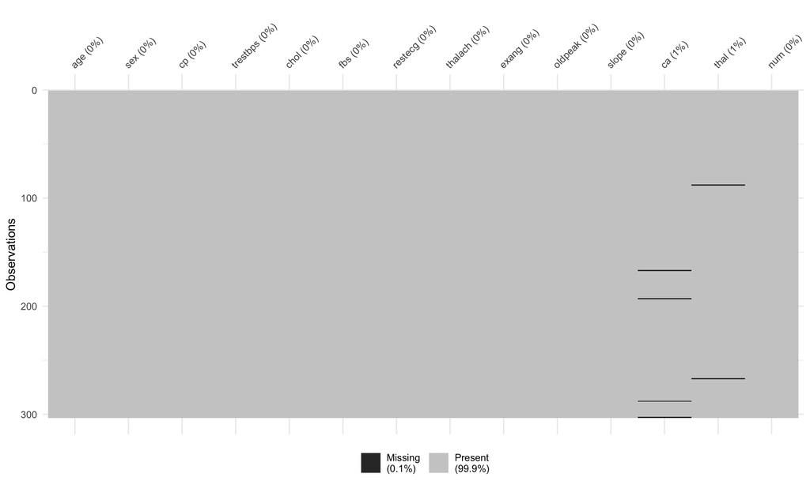

```r
# Visualizando o padrão de valores ausentes
vis_miss(heart_data)
```

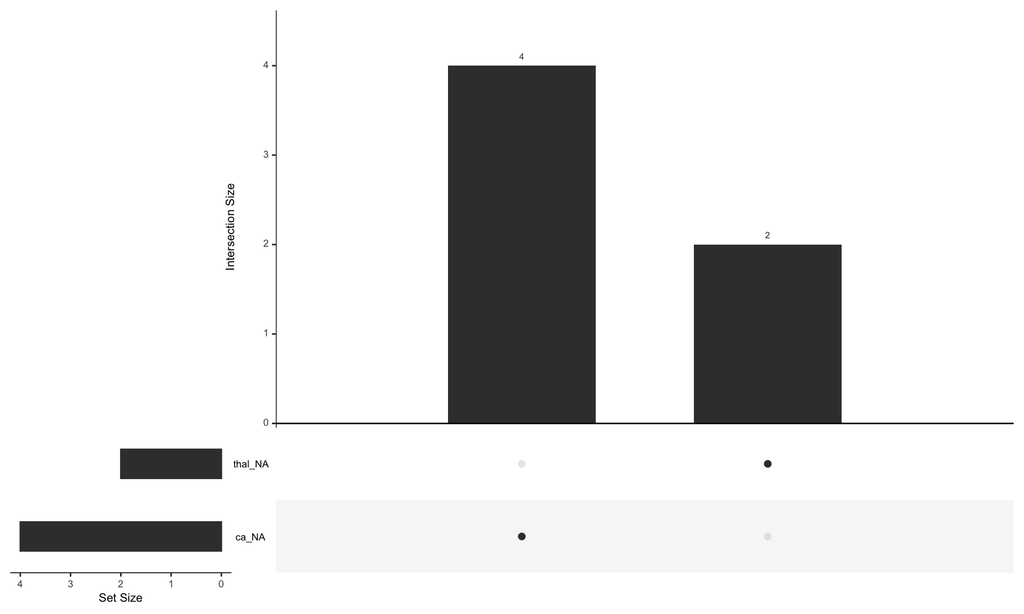

```r
# Visualização mais detalhada dos padrões de valores ausentes
gg_miss_upset(heart_data)
```

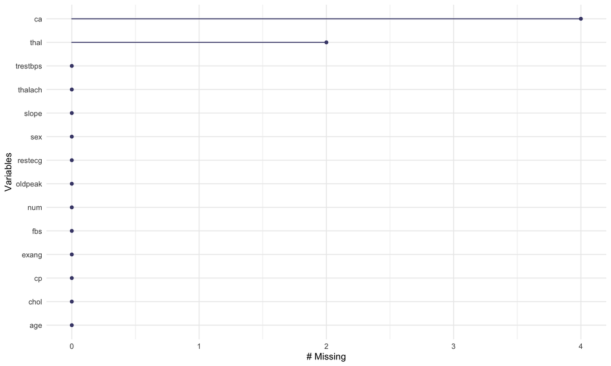

```r
# Proporção de valores ausentes por variável
gg_miss_var(heart_data)
```

### Tratamento de Valores Ausentes

Existem várias abordagens para lidar com valores ausentes:

1. **Exclusão**: Remover observações ou variáveis com muitos valores ausentes
2. **Imputação por média/mediana**: Substituir valores ausentes pela média ou mediana
3. **Imputação por KNN**: Usar k vizinhos mais próximos para estimar valores ausentes
4. **Imputação múltipla**: Gerar múltiplas imputações e combinar resultados

Vamos implementar algumas dessas abordagens:

```r
# 1. Exclusão de observações com valores ausentes (se forem poucos)
heart_complete <- na.omit(heart_data)
cat("Dimensões após remoção de valores ausentes:", dim(heart_complete), "\n")
```

```
## Dimensões após remoção de valores ausentes: 297 14
```

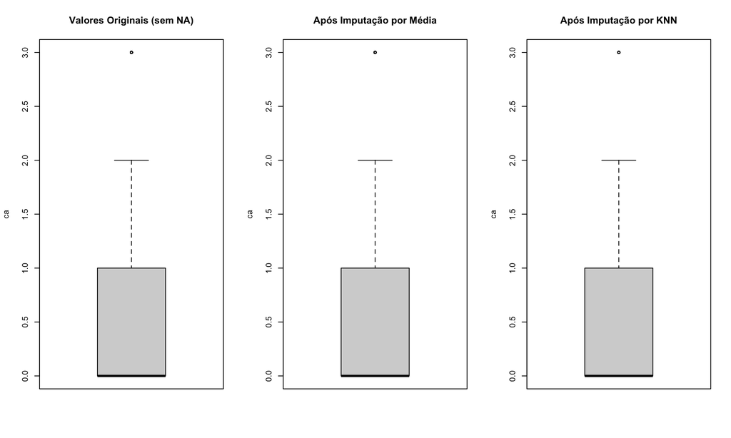

```r
# 2. Imputação por média (apenas para variáveis numéricas)
heart_imp_mean <- heart_data
for(i in 1:ncol(heart_data)) {
  if(is.numeric(heart_data[,i])) {
    heart_imp_mean[is.na(heart_data[,i]), i] <- mean(heart_data[,i], na.rm = TRUE)
  }
}

# 3. Imputação por KNN (mais sofisticado)
heart_imp_knn <- kNN(heart_data, k = 5)

# Comparando os métodos (para a variável 'ca', por exemplo)
if(sum(is.na(heart_data$ca)) > 0) {
  original_vals <- heart_data$ca[!is.na(heart_data$ca)]
  mean_imp_vals <- heart_imp_mean$ca
  knn_imp_vals <- heart_imp_knn$ca

  par(mfrow = c(1, 3))
  boxplot(original_vals, main = "Valores Originais (sem NA)", ylab = "ca")
  boxplot(mean_imp_vals, main = "Após Imputação por Média", ylab = "ca")
  boxplot(knn_imp_vals, main = "Após Imputação por KNN", ylab = "ca")
  par(mfrow = c(1, 1))
}
```

## Identificação de Outliers

Os outliers são observações que se desviam significativamente do padrão geral dos dados. Podem representar erros ou casos genuinamente incomuns.

### Detecção Univariada de Outliers

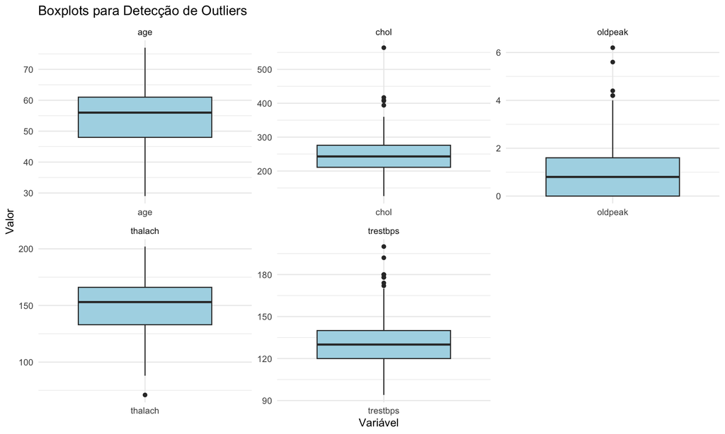

```r
# Vamos analisar algumas variáveis numéricas chave
vars_numericas <- c("age", "trestbps", "chol", "thalach", "oldpeak")

# Boxplots para detecção visual de outliers
heart_long <- heart_complete %>%
  select(all_of(vars_numericas)) %>%
  pivot_longer(cols = everything(),
               names_to = "variable",
               values_to = "value")

ggplot(heart_long, aes(x = variable, y = value)) +
  geom_boxplot(fill = "lightblue") +
  facet_wrap(~ variable, scales = "free") +
  theme_minimal() +
  labs(title = "Boxplots para Detecção de Outliers",
       x = "Variável", y = "Valor")
```

```r
# Teste de Grubbs para detecção formal de outliers
for(var in vars_numericas) {
  cat("\nTeste de Grubbs para", var, ":\n")
  test_result <- grubbs.test(heart_complete[[var]])
  print(test_result)
}
```

```
##
## Teste de Grubbs para age :
##
##  Grubbs test for one outlier
##
## data:  heart_complete[[var]]
## G = 2.8224, U = 0.9730, p-value = 0.6713
## alternative hypothesis: lowest value 29 is an outlier
##
##
## Teste de Grubbs para trestbps :
##
##  Grubbs test for one outlier
##
## data:  heart_complete[[var]]
## G = 3.84547, U = 0.94987, p-value = 0.01478
## alternative hypothesis: highest value 200 is an outlier
##
##
## Teste de Grubbs para chol :
##
##  Grubbs test for one outlier
##
## data:  heart_complete[[var]]
## G = 6.08970, U = 0.87429, p-value = 4.714e-08
## alternative hypothesis: highest value 564 is an outlier
##
##
## Teste de Grubbs para thalach :
##
##  Grubbs test for one outlier
##
## data:  heart_complete[[var]]
## G = 3.42607, U = 0.96021, p-value = 0.08083
## alternative hypothesis: lowest value 71 is an outlier
##
##
## Teste de Grubbs para oldpeak :
##
##  Grubbs test for one outlier
##
## data:  heart_complete[[var]]
## G = 4.41158, U = 0.93403, p-value = 0.001092
## alternative hypothesis: highest value 6.2 is an outlier
```

### Detecção Multivariada de Outliers

A detecção multivariada considera a estrutura de correlação entre as variáveis:

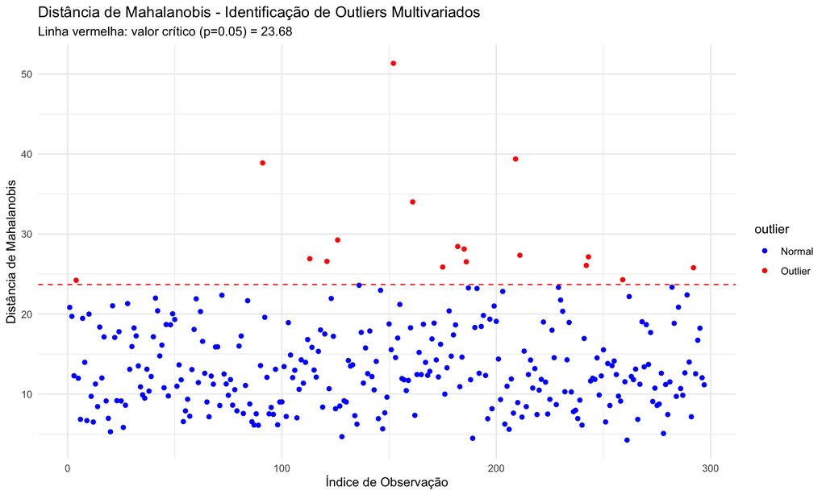

```r
# Selecionando apenas variáveis numéricas para o cálculo da distância de Mahalanobis
heart_num <- heart_complete %>%
  select_if(is.numeric)

# Calculando a distância de Mahalanobis
mahal_dist <- mahalanobis(heart_num,
                         colMeans(heart_num),
                         cov(heart_num))

# Adicionando as distâncias ao dataframe
heart_complete$mahal_dist <- mahal_dist

# Identificando outliers usando um limiar baseado na distribuição qui-quadrado
# O grau de liberdade é igual ao número de variáveis
dof <- ncol(heart_num)
critical_value <- qchisq(0.95, df = dof)

heart_complete$outlier <- ifelse(heart_complete$mahal_dist > critical_value, "Outlier", "Normal")

# Visualizando as distâncias
ggplot(heart_complete, aes(x = seq_along(mahal_dist), y = mahal_dist, color = outlier)) +
  geom_point() +
  geom_hline(yintercept = critical_value, linetype = "dashed", color = "red") +
  scale_color_manual(values = c("Normal" = "blue", "Outlier" = "red")) +
  labs(title = "Distância de Mahalanobis - Identificação de Outliers Multivariados",
       x = "Índice de Observação", y = "Distância de Mahalanobis",
       subtitle = paste("Linha vermelha: valor crítico (p=0.05) =", round(critical_value, 2))) +
  theme_minimal()
```

### Tratamento de Outliers

Existem várias abordagens para lidar com outliers:

1. **Verificação**: Confirmar se são erros de medida ou entrada
2. **Remoção**: Excluir os outliers (com cautela)
3. **Transformação**: Aplicar transformações que reduzam o impacto de valores extremos
4. **Winsorização**: Substituir valores extremos pelos percentis (ex: 5% e 95%)

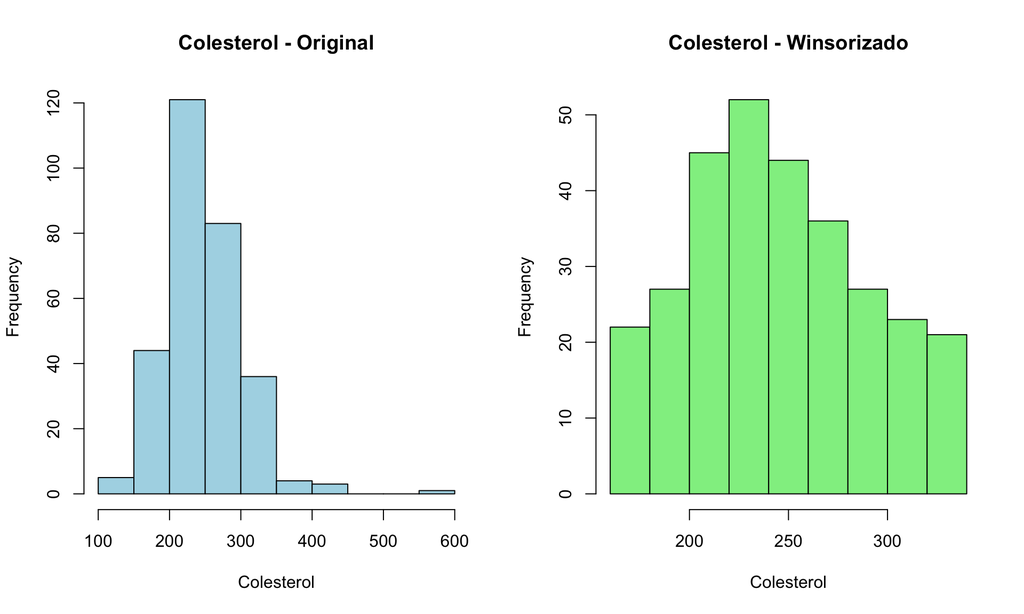

```r
# Exemplo: Winsorização da variável 'chol' (colesterol)
chol_95 <- quantile(heart_complete$chol, 0.95)
chol_05 <- quantile(heart_complete$chol, 0.05)

heart_winsor <- heart_complete
heart_winsor$chol_winsor <- heart_complete$chol
heart_winsor$chol_winsor[heart_winsor$chol_winsor > chol_95] <- chol_95
heart_winsor$chol_winsor[heart_winsor$chol_winsor < chol_05] <- chol_05

# Comparando original vs. winsorizado
par(mfrow = c(1, 2))
hist(heart_complete$chol, main = "Colesterol - Original",
     xlab = "Colesterol", col = "lightblue")
hist(heart_winsor$chol_winsor, main = "Colesterol - Winsorizado",
     xlab = "Colesterol", col = "lightgreen")
```

```r
par(mfrow = c(1, 1))
```

## Métodos de Padronização e Transformação

Em análise multivariada, frequentemente precisamos padronizar ou transformar variáveis para garantir comparabilidade ou melhorar distribuições.

### Padronização (Z-score)

Transforma variáveis para média 0 e desvio padrão 1:

```r
# Padronizando variáveis numéricas
heart_scaled <- heart_complete %>%
  select_if(is.numeric) %>%
  scale() %>%
  as.data.frame()

# Comparando estatísticas antes e depois da padronização
cat("Estatísticas antes da padronização:\n")
```

```
## Estatísticas antes da padronização:
```

```r
apply(heart_complete %>% select_if(is.numeric), 2, function(x) c(mean = mean(x), sd = sd(x)))
```

```
##            age       sex        cp  trestbps      chol       fbs   restecg
## mean 54.542088 0.6767677 3.1582492 131.69360 247.35017 0.1447811 0.9966330
## sd    9.049736 0.4685000 0.9648594  17.76281  51.99758 0.3524739 0.9949138
##        thalach     exang  oldpeak     slope        ca     thal       num
## mean 149.59933 0.3265993 1.055556 1.6026936 0.6767677 4.730640 0.9461279
## sd    22.94156 0.4697608 1.166123 0.6181868 0.9389645 1.938629 1.2345505
##      mahal_dist
## mean  13.952862
## sd     6.264272
```

```r
cat("\nEstatísticas após padronização:\n")
```

```
##
## Estatísticas após padronização:
```

```r
apply(heart_scaled, 2, function(x) c(mean = mean(x), sd = sd(x)))
```

```
##                age          sex            cp     trestbps          chol
## mean -6.504337e-17 1.353201e-16 -7.999587e-17 5.407197e-16 -2.169981e-16
## sd    1.000000e+00 1.000000e+00  1.000000e+00 1.000000e+00  1.000000e+00
##               fbs       restecg      thalach        exang       oldpeak
## mean -2.09335e-17 -1.644775e-17 5.270756e-16 9.457455e-17 -2.082135e-16
## sd    1.00000e+00  1.000000e+00 1.000000e+00 1.000000e+00  1.000000e+00
##             slope            ca          thal           num   mahal_dist
## mean 4.037175e-17 -1.368154e-16 -1.484035e-16 -7.375787e-17 5.652044e-16
## sd   1.000000e+00  1.000000e+00  1.000000e+00  1.000000e+00 1.000000e+00
```

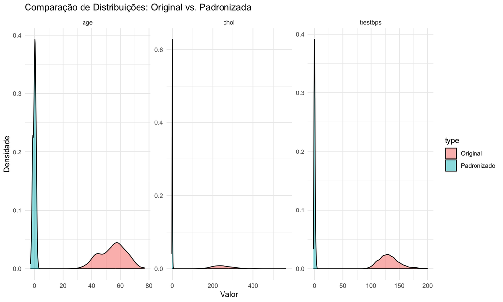

```r
# Visualizando o efeito da padronização
heart_long_orig <- heart_complete %>%
  select(age, trestbps, chol) %>%
  pivot_longer(cols = everything(),
               names_to = "variable",
               values_to = "value") %>%
  mutate(type = "Original")

heart_long_scaled <- heart_scaled %>%
  select(age, trestbps, chol) %>%
  pivot_longer(cols = everything(),
               names_to = "variable",
               values_to = "value") %>%
  mutate(type = "Padronizado")

rbind(heart_long_orig, heart_long_scaled) %>%
  ggplot(aes(x = value, fill = type)) +
  geom_density(alpha = 0.5) +
  facet_wrap(~ variable, scales = "free") +
  theme_minimal() +
  labs(title = "Comparação de Distribuições: Original vs. Padronizada",
       x = "Valor", y = "Densidade")
```

### Transformações para Normalidade

Quando a normalidade é importante, podemos aplicar transformações:

```r
# Verificando a assimetria das variáveis
skewness_values <- apply(heart_complete %>% select_if(is.numeric), 2, skew)
print(skewness_values)
```

```
##          age          sex           cp     trestbps         chol          fbs
## -0.217559560 -0.752070487 -0.835901980  0.693014179  1.106826979  2.008788724
##      restecg      thalach        exang      oldpeak        slope           ca
##  0.006699597 -0.531132648  0.735765216  1.234562315  0.505299162  1.167659890
##         thal          num   mahal_dist
##  0.245275202  1.036009457  1.543818964
```

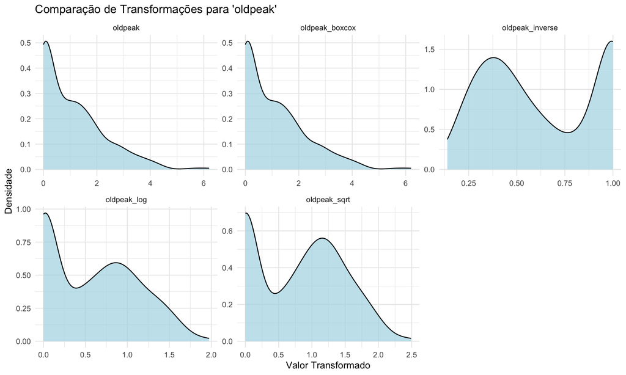

```r
# Aplicando diferentes transformações à variável 'oldpeak' (assimétrica)
heart_transform <- heart_complete %>%
  mutate(
    oldpeak_log = log(oldpeak + 1),       # Log (adicionamos 1 para evitar log(0))
    oldpeak_sqrt = sqrt(oldpeak),          # Raiz quadrada
    oldpeak_inverse = 1/(oldpeak + 1),     # Inversa
    oldpeak_boxcox = if(all(oldpeak > 0)) car::powerTransform(oldpeak)$y else oldpeak  # Box-Cox
  )

# Comparando distribuições
oldpeak_trans <- heart_transform %>%
  select(starts_with("oldpeak")) %>%
  pivot_longer(cols = everything(),
               names_to = "transformation",
               values_to = "value")

ggplot(oldpeak_trans, aes(x = value)) +
  geom_density(fill = "lightblue", alpha = 0.7) +
  facet_wrap(~ transformation, scales = "free") +
  theme_minimal() +
  labs(title = "Comparação de Transformações para 'oldpeak'",
       x = "Valor Transformado", y = "Densidade")
```

### Normalização Min-Max

Quando queremos valores em um intervalo específico (ex: 0 a 1):

```r
# Função de normalização min-max
normalize <- function(x) {
  return ((x - min(x)) / (max(x) - min(x)))
}

# Aplicando normalização min-max às variáveis numéricas
heart_normalized <- heart_complete %>%
  select_if(is.numeric) %>%
  mutate(across(everything(), normalize)) %>%
  as.data.frame()

# Verificando o resultado da normalização
summary(heart_normalized)
```

```
##       age              sex               cp            trestbps
##  Min.   :0.0000   Min.   :0.0000   Min.   :0.0000   Min.   :0.0000
##  1st Qu.:0.3958   1st Qu.:0.0000   1st Qu.:0.6667   1st Qu.:0.2453
##  Median :0.5625   Median :1.0000   Median :0.6667   Median :0.3396
##  Mean   :0.5321   Mean   :0.6768   Mean   :0.7194   Mean   :0.3556
##  3rd Qu.:0.6667   3rd Qu.:1.0000   3rd Qu.:1.0000   3rd Qu.:0.4340
##  Max.   :1.0000   Max.   :1.0000   Max.   :1.0000   Max.   :1.0000
##       chol             fbs            restecg          thalach
##  Min.   :0.0000   Min.   :0.0000   Min.   :0.0000   Min.   :0.0000
##  1st Qu.:0.1941   1st Qu.:0.0000   1st Qu.:0.0000   1st Qu.:0.4733
##  Median :0.2671   Median :0.0000   Median :0.5000   Median :0.6260
##  Mean   :0.2771   Mean   :0.1448   Mean   :0.4983   Mean   :0.6000
##  3rd Qu.:0.3425   3rd Qu.:0.0000   3rd Qu.:1.0000   3rd Qu.:0.7252
##  Max.   :1.0000   Max.   :1.0000   Max.   :1.0000   Max.   :1.0000
##      exang           oldpeak           slope              ca
##  Min.   :0.0000   Min.   :0.0000   Min.   :0.0000   Min.   :0.0000
##  1st Qu.:0.0000   1st Qu.:0.0000   1st Qu.:0.0000   1st Qu.:0.0000
##  Median :0.0000   Median :0.1290   Median :0.5000   Median :0.0000
##  Mean   :0.3266   Mean   :0.1703   Mean   :0.3013   Mean   :0.2256
##  3rd Qu.:1.0000   3rd Qu.:0.2581   3rd Qu.:0.5000   3rd Qu.:0.3333
##  Max.   :1.0000   Max.   :1.0000   Max.   :1.0000   Max.   :1.0000
##       thal             num           mahal_dist
##  Min.   :0.0000   Min.   :0.0000   Min.   :0.0000
##  1st Qu.:0.0000   1st Qu.:0.0000   1st Qu.:0.1080
##  Median :0.0000   Median :0.0000   Median :0.1753
##  Mean   :0.4327   Mean   :0.2365   Mean   :0.2064
##  3rd Qu.:1.0000   3rd Qu.:0.5000   3rd Qu.:0.2858
##  Max.   :1.0000   Max.   :1.0000   Max.   :1.0000
```

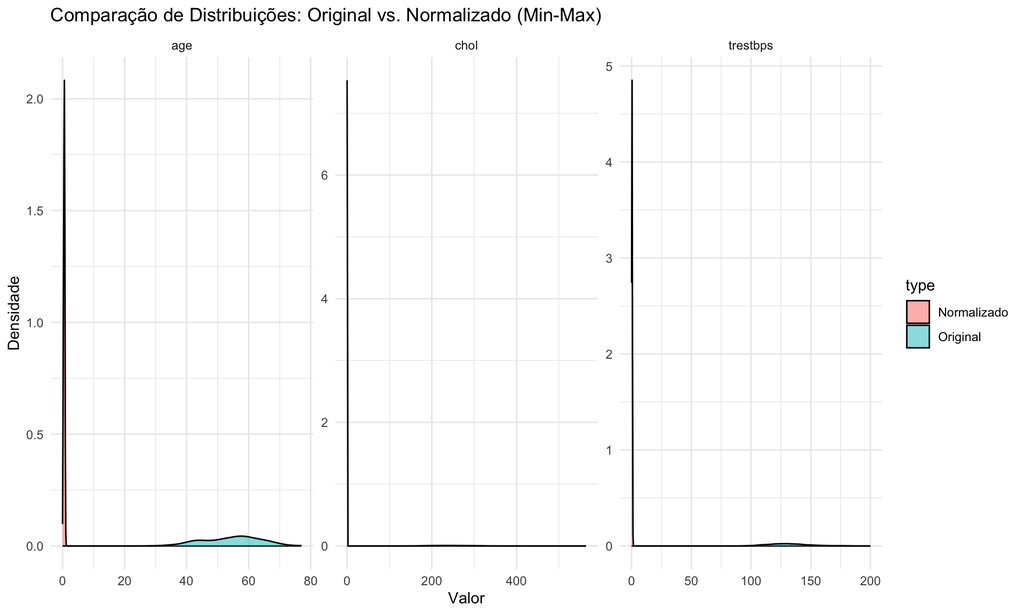

```r
# Exemplo de visualização
heart_long_norm <- heart_normalized %>%
  select(age, trestbps, chol) %>%
  pivot_longer(cols = everything(),
               names_to = "variable",
               values_to = "value") %>%
  mutate(type = "Normalizado")

rbind(heart_long_orig, heart_long_norm) %>%
  ggplot(aes(x = value, fill = type)) +
  geom_density(alpha = 0.5) +
  facet_wrap(~ variable, scales = "free") +
  theme_minimal() +
  labs(title = "Comparação de Distribuições: Original vs. Normalizado (Min-Max)",
       x = "Valor", y = "Densidade")
```

## Análise Exploratória Básica

Após o tratamento de valores ausentes, outliers e transformações, vamos realizar algumas análises exploratórias básicas:

### Estatísticas Descritivas

```r
# Estatísticas descritivas detalhadas
describe(heart_complete %>% select_if(is.numeric))
```

```
##            vars   n   mean    sd median trimmed   mad    min    max range  skew
## age           1 297  54.54  9.05  56.00   54.73  8.90  29.00  77.00  48.0 -0.22
## sex           2 297   0.68  0.47   1.00    0.72  0.00   0.00   1.00   1.0 -0.75
## cp            3 297   3.16  0.96   3.00    3.29  1.48   1.00   4.00   3.0 -0.84
## trestbps      4 297 131.69 17.76 130.00  130.48 14.83  94.00 200.00 106.0  0.69
## chol          5 297 247.35 52.00 243.00  244.70 47.44 126.00 564.00 438.0  1.11
## fbs           6 297   0.14  0.35   0.00    0.06  0.00   0.00   1.00   1.0  2.01
## restecg       7 297   1.00  0.99   1.00    1.00  1.48   0.00   2.00   2.0  0.01
## thalach       8 297 149.60 22.94 153.00  150.91 22.24  71.00 202.00 131.0 -0.53
## exang         9 297   0.33  0.47   0.00    0.28  0.00   0.00   1.00   1.0  0.74
## oldpeak      10 297   1.06  1.17   0.80    0.88  1.19   0.00   6.20   6.2  1.23
## slope        11 297   1.60  0.62   2.00    1.54  1.48   1.00   3.00   2.0  0.51
## ca           12 297   0.68  0.94   0.00    0.51  0.00   0.00   3.00   3.0  1.17
## thal         13 297   4.73  1.94   3.00    4.67  0.00   3.00   7.00   4.0  0.25
## num          14 297   0.95  1.23   0.00    0.76  0.00   0.00   4.00   4.0  1.04
## mahal_dist   15 297  13.95  6.26  12.49   13.31  5.66   4.23  51.33  47.1  1.54
##            kurtosis   se
## age           -0.55 0.53
## sex           -1.44 0.03
## cp            -0.44 0.06
## trestbps       0.76 1.03
## chol           4.30 3.02
## fbs            2.04 0.02
## restecg       -1.99 0.06
## thalach       -0.09 1.33
## exang         -1.46 0.03
## oldpeak        1.44 0.07
## slope         -0.65 0.04
## ca             0.19 0.05
## thal          -1.91 0.11
## num           -0.21 0.07
## mahal_dist     4.83 0.36
```

```r
# Análise por grupo (presença de doença cardíaca)
heart_complete$num <- factor(heart_complete$num,
                            levels = c(0, 1, 2, 3, 4),
                            labels = c("Ausente", "Leve", "Moderada", "Grave", "Muito Grave"))

# Comparação das médias por grupo diagnóstico
heart_complete %>%
  group_by(num) %>%
  summarise(across(all_of(c("age", "trestbps", "chol", "thalach")),
                   list(media = mean, dp = sd),
                   .names = "{.col}_{.fn}"))
```

```
## # A tibble: 5 × 9
##   num         age_media age_dp trestbps_media trestbps_dp chol_media chol_dp
##   <fct>           <dbl>  <dbl>          <dbl>       <dbl>      <dbl>   <dbl>
## 1 Ausente          52.6   9.55           129.        16.4       243.    53.8
## 2 Leve             55.6   7.89           133.        18.2       249.    41.1
## 3 Moderada         58.2   7.25           134.        18.1       261.    53.7
## 4 Grave            56     7.78           135.        21.7       246.    51.7
## 5 Muito Grave      59.7   9.42           139.        17.2       253.    66.3
## # ℹ 2 more variables: thalach_media <dbl>, thalach_dp <dbl>
```

### Análise de Correlações

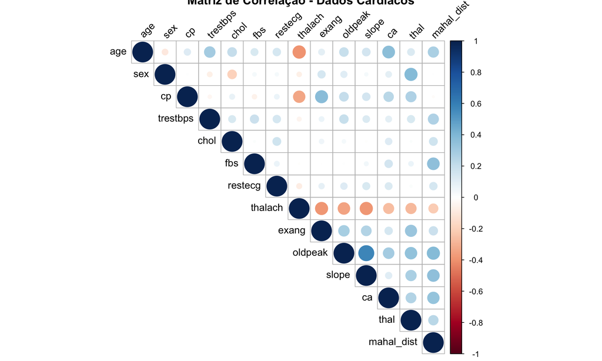

```r
# Matriz de correlação das variáveis numéricas
cor_matrix <- cor(heart_complete %>% select_if(is.numeric),
                 use = "pairwise.complete.obs")

# Visualização da matriz de correlação
corrplot(cor_matrix, method = "circle", type = "upper",
         tl.col = "black", tl.srt = 45,
         title = "Matriz de Correlação - Dados Cardíacos")
```

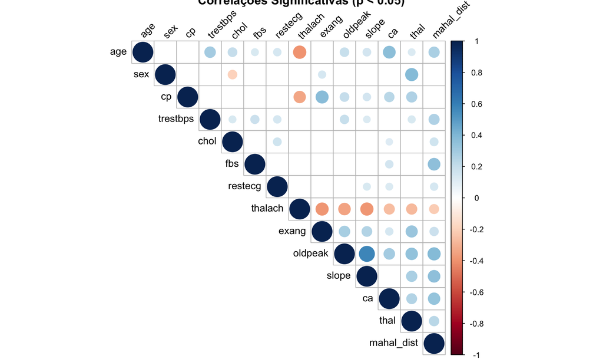

```r
# Teste de significância das correlações
cor_p <- cor.mtest(heart_complete %>% select_if(is.numeric))
corrplot(cor_matrix, p.mat = cor_p$p, sig.level = 0.05,
         insig = "blank", method = "circle", type = "upper",
         tl.col = "black", tl.srt = 45,
         title = "Correlações Significativas (p < 0.05)")
```

### Visualizações Multivariadas

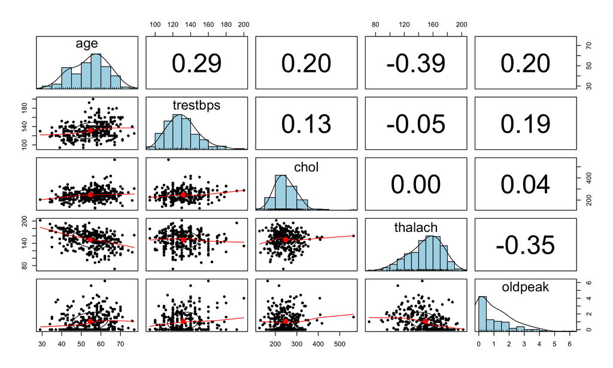

```r
# Matriz de gráficos de dispersão para algumas variáveis selecionadas
pairs.panels(heart_complete %>%
              select(age, trestbps, chol, thalach, oldpeak),
            method = "pearson",   # Método de correlação
            hist.col = "lightblue",
            density = TRUE,       # Mostrar densidade
            ellipses = TRUE)      # Mostrar elipses de correlação
```

## Preparação Final para Análises Futuras

Agora que realizamos o tratamento de valores ausentes, outliers e transformações, vamos preparar um conjunto de dados limpo para futuras análises multivariadas:

```r
# Selecionando o conjunto final após todas as transformações
# Usaremos os dados padronizados para variáveis numéricas
heart_final <- heart_complete %>%
  select(-mahal_dist, -outlier)  # Removendo colunas de diagnóstico

# Convertendo variáveis categóricas para fatores
heart_final$sex <- factor(heart_final$sex, levels = c(0, 1), labels = c("Feminino", "Masculino"))
heart_final$cp <- factor(heart_final$cp, levels = c(1, 2, 3, 4),
                        labels = c("Angina Típica", "Angina Atípica", "Dor Não-Anginal", "Assintomático"))
heart_final$fbs <- factor(heart_final$fbs, levels = c(0, 1),
                         labels = c("<=120 mg/dl", ">120 mg/dl"))
heart_final$exang <- factor(heart_final$exang, levels = c(0, 1),
                           labels = c("Não", "Sim"))

# Verificando a estrutura final dos dados
str(heart_final)
```

```
## 'data.frame':    297 obs. of  14 variables:
##  $ age     : num  63 67 67 37 41 56 62 57 63 53 ...
##  $ sex     : Factor w/ 2 levels "Feminino","Masculino": 2 2 2 2 1 2 1 1 2 2 ...
##  $ cp      : Factor w/ 4 levels "Angina Típica",..: 1 4 4 3 2 2 4 4 4 4 ...
##  $ trestbps: num  145 160 120 130 130 120 140 120 130 140 ...
##  $ chol    : num  233 286 229 250 204 236 268 354 254 203 ...
##  $ fbs     : Factor w/ 2 levels "<=120 mg/dl",..: 2 1 1 1 1 1 1 1 1 2 ...
##  $ restecg : num  2 2 2 0 2 0 2 0 2 2 ...
##  $ thalach : num  150 108 129 187 172 178 160 163 147 155 ...
##  $ exang   : Factor w/ 2 levels "Não","Sim": 1 2 2 1 1 1 1 2 1 2 ...
##  $ oldpeak : num  2.3 1.5 2.6 3.5 1.4 0.8 3.6 0.6 1.4 3.1 ...
##  $ slope   : num  3 2 2 3 1 1 3 1 2 3 ...
##  $ ca      : num  0 3 2 0 0 0 2 0 1 0 ...
##  $ thal    : num  6 3 7 3 3 3 3 3 7 7 ...
##  $ num     : Factor w/ 5 levels "Ausente","Leve",..: 1 3 2 1 1 1 4 1 3 2 ...
##  - attr(*, "na.action")= 'omit' Named int [1:6] 88 167 193 267 288 303
##   ..- attr(*, "names")= chr [1:6] "88" "167" "193" "267" ...
```

```r
# Salvando o conjunto de dados preparado
write.csv(heart_final, "heart_preparado.csv", row.names = FALSE)

# Também salvamos uma versão com variáveis numéricas padronizadas
heart_final_scaled <- heart_final
heart_final_scaled[, sapply(heart_final, is.numeric)] <- scale(heart_final[, sapply(heart_final, is.numeric)])
write.csv(heart_final_scaled, "heart_preparado_scaled.csv", row.names = FALSE)
```

## Resumo e Próximos Passos

Os dados estão agora prontos para as seguintes análises multivariadas que iremos estudar ao longo da disciplina: - Análise de Componentes Principais (PCA) - Análise de Clusters - Análise Discriminante

## Hora de Praticar

Agora, vamos praticar o que aprendemos com um exercício guiado usando dados de saúde:

### Exercício: Análise de Dados do Diabetes

Para este exercício, utilizaremos o conjunto de dados “Pima Indians Diabetes”, que contém informações sobre mulheres indígenas Pima com idade de pelo menos 21 anos e inclui variáveis relacionadas a fatores de risco para diabetes e o diagnóstico da doença.

1. Carregue o conjunto de dados:

   ```r
   # Carregando dados de diabetes
   url <- "https://raw.githubusercontent.com/jbrownlee/Datasets/master/pima-indians-diabetes.data.csv"

   # Alternativamente, se o URL não estiver acessível:
   # install.packages("mlbench")
   # library(mlbench)
   # data(PimaIndiansDiabetes)
   # diabetes <- PimaIndiansDiabetes

   # Carregar diretamente do URL
   colunas <- c("pregnancies", "glucose", "blood_pressure", "skin_thickness",
                "insulin", "bmi", "diabetes_pedigree", "age", "outcome")
   diabetes <- read.csv(url, header = FALSE, col.names = colunas)

   # Convertendo a variável de resultado para fator
   diabetes$outcome <- factor(diabetes$outcome, levels = c(0, 1),
                             labels = c("Negativo", "Positivo"))

   # Examinando a estrutura dos dados
   str(diabetes)
   ```

2. Realize as seguintes tarefas:
   1. **Identificação e tratamento de valores ausentes**:
      - Neste conjunto de dados, valores zero em certas variáveis fisiológicas (glucose, blood_pressure, skin_thickness, insulin, bmi) são biologicamente implausíveis e provavelmente representam valores ausentes.
      - Identifique e trate esses valores como NA.
      - Visualize o padrão de valores ausentes.
      - Aplique um método apropriado de imputação.
   2. **Identificação e tratamento de outliers**:
      - Identifique outliers univariados em variáveis como glucose, insulin e bmi.
      - Aplique a distância de Mahalanobis para detectar outliers multivariados.
      - Proponha uma estratégia para lidar com os outliers identificados.
   3. **Padronização e transformação**:
      - Analise a distribuição das variáveis (especialmente insulin e diabetes_pedigree).
      - Aplique transformações apropriadas para normalizar as distribuições assimétricas.
      - Padronize todas as variáveis numéricas para comparabilidade.
   4. **Análise exploratória básica**:
      - Compare as estatísticas descritivas entre pacientes com e sem diabetes.
      - Calcule e visualize a matriz de correlação das variáveis.
      - Crie visualizações que mostrem as diferenças nas variáveis clínicas entre os dois grupos de diagnóstico.
3. Prepare e salve o conjunto de dados processado para futuras análises multivariadas.
4. Responda às seguintes perguntas:
   - Quais variáveis apresentam as diferenças mais significativas entre pacientes com e sem diabetes?
   - Quais variáveis estão mais fortemente correlacionadas com o diagnóstico de diabetes?
   - Com base na análise exploratória, quais fatores de risco parecem ser mais importantes para o desenvolvimento de diabetes nesta população?
   - Quais transformações foram mais eficazes para normalizar as distribuições das variáveis?

### Código Inicial para Ajudar

```r
# Carregar dados
url <- "https://raw.githubusercontent.com/jbrownlee/Datasets/master/pima-indians-diabetes.data.csv"
colunas <- c("pregnancies", "glucose", "blood_pressure", "skin_thickness",
            "insulin", "bmi", "diabetes_pedigree", "age", "outcome")
diabetes <- read.csv(url, header = FALSE, col.names = colunas)

# Convertendo a variável de resultado para fator
diabetes$outcome <- factor(diabetes$outcome, levels = c(0, 1),
                         labels = c("Negativo", "Positivo"))

# Examinando a estrutura dos dados
str(diabetes)
summary(diabetes)

# Verificando valores implausíveis (zeros em variáveis fisiológicas)
zeros_implausives <- data.frame(
  glucose = sum(diabetes$glucose == 0),
  blood_pressure = sum(diabetes$blood_pressure == 0),
  skin_thickness = sum(diabetes$skin_thickness == 0),
  insulin = sum(diabetes$insulin == 0),
  bmi = sum(diabetes$bmi == 0)
)
print(zeros_implausives)

# Tratar zeros como NA nas variáveis fisiológicas
diabetes_cleaned <- diabetes
diabetes_cleaned$glucose[diabetes_cleaned$glucose == 0] <- NA
diabetes_cleaned$blood_pressure[diabetes_cleaned$blood_pressure == 0] <- NA
diabetes_cleaned$skin_thickness[diabetes_cleaned$skin_thickness == 0] <- NA
diabetes_cleaned$insulin[diabetes_cleaned$insulin == 0] <- NA
diabetes_cleaned$bmi[diabetes_cleaned$bmi == 0] <- NA

# Verificando valores ausentes
colSums(is.na(diabetes_cleaned))

# Continue a partir daqui com:
# 1. Visualização de valores ausentes
# 2. Imputação
# 3. Detecção de outliers
# 4. Transformações
# 5. Análise exploratória
```